# eda slides

## **Google Play Store Exploratory Data Analysis 🦊**

#### by Garreth Lee (2022)

The Google Play Store plays host to 2.3 million apps, all with different purposes and user bases. While some apps will never see the light of day, others have been thriving and sitting atop the throne for years. With mountains of data at our disposal, an opportunity arises to clean, visualize, and extract meaningful insights from the millions of rows that are available to us.

### Press `Spacebar` to Continue ➡️ ...

# Data Loading and Initial Findings

```python
#Import necessary libraries

import pandas as pd
import numpy as np
import seaborn as sns
import matplotlib.pyplot as plt
import warnings


warnings.filterwarnings('ignore')
sns.set_theme(style='darkgrid', palette='deep')
```

```python
data = pd.read_csv("playstore.csv")
data.head()
```

|  | App Name | App Id | Category | Rating | Rating Count | Installs | Minimum Installs | Maximum Installs | Free | Price | ... | Developer Website | Developer Email | Released | Last Updated | Content Rating | Privacy Policy | Ad Supported | In App Purchases | Editors Choice | Scraped Time |
| --- | --- | --- | --- | --- | --- | --- | --- | --- | --- | --- | --- | --- | --- | --- | --- | --- | --- | --- | --- | --- | --- |
| 0 | Gakondo | com.ishakwe.gakondo | Adventure | 0.0 | 0.0 | 10+ | 10.0 | 15 | True | 0.0 | ... | https://beniyizibyose.tk/#/ | jean21101999@gmail.com | Feb 26, 2020 | Feb 26, 2020 | Everyone | https://beniyizibyose.tk/projects/ | False | False | False | 2021-06-15 20:19:35 |
| 1 | Ampere Battery Info | com.webserveis.batteryinfo | Tools | 4.4 | 64.0 | 5,000+ | 5000.0 | 7662 | True | 0.0 | ... | https://webserveis.netlify.app/ | webserveis@gmail.com | May 21, 2020 | May 06, 2021 | Everyone | https://dev4phones.wordpress.com/licencia-de-uso/ | True | False | False | 2021-06-15 20:19:35 |
| 2 | Vibook | com.doantiepvien.crm | Productivity | 0.0 | 0.0 | 50+ | 50.0 | 58 | True | 0.0 | ... | NaN | vnacrewit@gmail.com | Aug 9, 2019 | Aug 19, 2019 | Everyone | https://www.vietnamairlines.com/vn/en/terms-an... | False | False | False | 2021-06-15 20:19:35 |
| 3 | Smart City Trichy Public Service Vehicles 17UC... | cst.stJoseph.ug17ucs548 | Communication | 5.0 | 5.0 | 10+ | 10.0 | 19 | True | 0.0 | ... | http://www.climatesmarttech.com/ | climatesmarttech2@gmail.com | Sep 10, 2018 | Oct 13, 2018 | Everyone | NaN | True | False | False | 2021-06-15 20:19:35 |
| 4 | GROW.me | com.horodyski.grower | Tools | 0.0 | 0.0 | 100+ | 100.0 | 478 | True | 0.0 | ... | http://www.horodyski.com.pl | rmilekhorodyski@gmail.com | Feb 21, 2020 | Nov 12, 2018 | Everyone | http://www.horodyski.com.pl | False | False | False | 2021-06-15 20:19:35 |

5 rows × 24 columns

# Data Cleaning

First, let's drop the entries that are missing the app name, since it is difficult to impute data without this information.

```python
no_name_index = list(data[data['App Name'].isnull()].index)

data.drop(no_name_index, inplace=True)

data.head()
```

|  | App Name | App Id | Category | Rating | Rating Count | Installs | Minimum Installs | Maximum Installs | Free | Price | ... | Developer Website | Developer Email | Released | Last Updated | Content Rating | Privacy Policy | Ad Supported | In App Purchases | Editors Choice | Scraped Time |
| --- | --- | --- | --- | --- | --- | --- | --- | --- | --- | --- | --- | --- | --- | --- | --- | --- | --- | --- | --- | --- | --- |
| 0 | Gakondo | com.ishakwe.gakondo | Adventure | 0.0 | 0.0 | 10+ | 10.0 | 15 | True | 0.0 | ... | https://beniyizibyose.tk/#/ | jean21101999@gmail.com | Feb 26, 2020 | Feb 26, 2020 | Everyone | https://beniyizibyose.tk/projects/ | False | False | False | 2021-06-15 20:19:35 |
| 1 | Ampere Battery Info | com.webserveis.batteryinfo | Tools | 4.4 | 64.0 | 5,000+ | 5000.0 | 7662 | True | 0.0 | ... | https://webserveis.netlify.app/ | webserveis@gmail.com | May 21, 2020 | May 06, 2021 | Everyone | https://dev4phones.wordpress.com/licencia-de-uso/ | True | False | False | 2021-06-15 20:19:35 |
| 2 | Vibook | com.doantiepvien.crm | Productivity | 0.0 | 0.0 | 50+ | 50.0 | 58 | True | 0.0 | ... | NaN | vnacrewit@gmail.com | Aug 9, 2019 | Aug 19, 2019 | Everyone | https://www.vietnamairlines.com/vn/en/terms-an... | False | False | False | 2021-06-15 20:19:35 |
| 3 | Smart City Trichy Public Service Vehicles 17UC... | cst.stJoseph.ug17ucs548 | Communication | 5.0 | 5.0 | 10+ | 10.0 | 19 | True | 0.0 | ... | http://www.climatesmarttech.com/ | climatesmarttech2@gmail.com | Sep 10, 2018 | Oct 13, 2018 | Everyone | NaN | True | False | False | 2021-06-15 20:19:35 |
| 4 | GROW.me | com.horodyski.grower | Tools | 0.0 | 0.0 | 100+ | 100.0 | 478 | True | 0.0 | ... | http://www.horodyski.com.pl | rmilekhorodyski@gmail.com | Feb 21, 2020 | Nov 12, 2018 | Everyone | http://www.horodyski.com.pl | False | False | False | 2021-06-15 20:19:35 |

5 rows × 24 columns

Then, let's drop unecessary columns from the dataframe. These columns are 'unecessary' in the sense that we won't be able to analyze meaningful insights from the information within these columns, since they either contain duplicate information (`Free` and `Price`) that is present in other columns, or is just administrative data (`ID`s).

```python
cols_to_drop = ['Privacy Policy', 'Installs', 'Developer Website', 'Developer Email', 'Developer Id', 'App Id', 'Free', 'Scraped Time']

data = data.drop(columns=cols_to_drop)
```

Note:

- I decided to remove the `Installs` column because it displays similar information to the `Minimum Installs` and `Maximum Installs` columns. The only difference is that the `Installs` column is formatted as a threshold, while the other 2 columns gave out exact values.

# Missing Data

Now, let's take a look at null values within the dataset

I decided to create a new column `Average Installs`, which takes the mean value of `Minimum Installs` and `Maximum Installs` to derive this new column and dropped the 2 original columns.

```python
data['Average Installs'] = (data['Minimum Installs'] + data['Maximum Installs']) / 2
data = data.drop(columns = ['Minimum Installs', 'Maximum Installs'])
```

```python
missing_table(data)
```

|  | Count | Percentage |
| --- | --- | --- |
| Released | 71053 | 3.071975 |
| Rating | 22883 | 0.989346 |
| Rating Count | 22883 | 0.989346 |
| Minimum Android | 6530 | 0.282324 |
| Size | 196 | 0.008474 |
| Currency | 135 | 0.005837 |
| Average Installs | 107 | 0.004626 |
| App Name | 0 | 0.000000 |
| Category | 0 | 0.000000 |
| Price | 0 | 0.000000 |
| Last Updated | 0 | 0.000000 |
| Content Rating | 0 | 0.000000 |
| Ad Supported | 0 | 0.000000 |
| In App Purchases | 0 | 0.000000 |
| Editors Choice | 0 | 0.000000 |

As you can see, there isn't much downside to dropping the entirety of the rows with missing data, since less than 5% of the data would be dropped. This wouldn't cause a meaningful effect on the insights that we are able to generate from the data.

Therefore, let's drop these missing values.

```python
data_dropped = data.dropna(subset=['Released', 'Rating', 'Minimum Android', 'Rating Count', 'Size', 'Average Installs'])
total_dropped = data.shape[0] - data_dropped.shape[0]

print(f'A total of {total_dropped} rows ({round(total_dropped / data.shape[0] * 100,2)}%) were dropped')
```

```
A total of 77613 rows (3.36%) were dropped
```

# Reformatting and Encoding Data

Some columns with the `object` and `float` dtype make more sense to be represented as an int. For example, the rating count column, which represents the number of people giving ratings makes more sense to be represented as an integer. Other columns also need to be rounded up, such as the `Price` and `Rating` columns.

Also, I will simplify some columns to remove unecessary clutter, with one example being the `Minimum Android` column which has the 'and up' phrase in every single entry. This doesn't really provide any additional information, so it is best to remove it to declutter our dataset.

TODO:

- Change the `Rating Count` dtype to int
- Reformat release and update dates
- Round up the `Rating, Price, and Average Installs` columns to 2 decimal points
- Encode `Currency` to a categorical variable
  - Figure out a way to deal with different currency pricing
- Remove the 'and up' in the `Minimum Android` column for legibility

And away.. we go!

```python
#Change the RatingCount dtype to int
data_dropped['Rating Count'] = data_dropped['Rating Count'].astype(int)

#Round up the Rating, Price, and Average Installs columns to 2 decimal points
data_dropped[['Rating', 'Price','Average Installs']] = data_dropped[['Rating', 'Price', 'Average Installs']].round(2)

#Reformat release and update dates to show months and year (i.e. Release Month and Release Year, etc.)
data_dropped['Released'] = pd.to_datetime(data['Released'], format='%b %d, %Y')
data_dropped['Last Updated'] = pd.to_datetime(data['Last Updated'], format='%b %d, %Y')
```

```python
data_dropped['Currency'].value_counts()
```

```
USD    2234093
XXX       1193
EUR          6
INR          5
GBP          3
CAD          2
VND          1
BRL          1
KRW          1
TRY          1
SGD          1
AUD          1
ZAR          1
Name: Currency, dtype: int64
```

Since 99% of apps are in USD, we can make a categorical variable (`inUSD`) that represents whether or not an app was in USD or not.

However, we also want to take note of paid apps with non-USD currencies, since the pricing in their respective currencies don't match the US dollar. We have to take care of this as well.

```python
#Find apps that are in non-USD currencies and are paid
data_dropped.loc[(data['Currency'] != 'USD') & (data['Price'] != 0)]
```

|  | App Name | Category | Rating | Rating Count | Price | Currency | Size | Minimum Android | Released | Last Updated | Content Rating | Ad Supported | In App Purchases | Editors Choice | Average Installs |
| --- | --- | --- | --- | --- | --- | --- | --- | --- | --- | --- | --- | --- | --- | --- | --- |

Huh, that was lucky! It seems that no apps sold in non-USD currencies were paid, so we don't have to worry about currency conversion. Yay!

Now, we encode the currencies.

```python
#Encode Currency to a categorical variable
data_dropped['In USD'] = 1
data_dropped.loc[data_dropped['Currency'] != 'USD', 'In USD'] = 0
data_dropped['In USD'].value_counts()
#We can drop the Currency column now
data_dropped = data_dropped.drop(['Currency'], axis=1)

#Remove the 'and up' in the Minimum Android column for legibility
data_dropped['Minimum Android'] = data_dropped['Minimum Android'].apply(lambda x: x.split()[0])
```

Now let's take a look at the data

```python
pd.set_option('display.float_format', lambda x: f'{x:,.3f}')

data_dropped.head()
```

|  | App Name | Category | Rating | Rating Count | Price | Size | Minimum Android | Released | Last Updated | Content Rating | Ad Supported | In App Purchases | Editors Choice | Average Installs | In USD |
| --- | --- | --- | --- | --- | --- | --- | --- | --- | --- | --- | --- | --- | --- | --- | --- |
| 0 | Gakondo | Adventure | 0.000 | 0 | 0.000 | 10M | 7.1 | 2020-02-26 | 2020-02-26 | Everyone | False | False | False | 12.500 | 1 |
| 1 | Ampere Battery Info | Tools | 4.400 | 64 | 0.000 | 2.9M | 5.0 | 2020-05-21 | 2021-05-06 | Everyone | True | False | False | 6,331.000 | 1 |
| 2 | Vibook | Productivity | 0.000 | 0 | 0.000 | 3.7M | 4.0.3 | 2019-08-09 | 2019-08-19 | Everyone | False | False | False | 54.000 | 1 |
| 3 | Smart City Trichy Public Service Vehicles 17UC... | Communication | 5.000 | 5 | 0.000 | 1.8M | 4.0.3 | 2018-09-10 | 2018-10-13 | Everyone | True | False | False | 14.500 | 1 |
| 4 | GROW.me | Tools | 0.000 | 0 | 0.000 | 6.2M | 4.1 | 2020-02-21 | 2018-11-12 | Everyone | False | False | False | 289.000 | 1 |

And now, for the most satisfying part of the data cleaning process

```python
#prints out the number of null values in the dataset
data_dropped.isnull().sum()
```

```
App Name            0
Category            0
Rating              0
Rating Count        0
Price               0
Size                0
Minimum Android     0
Released            0
Last Updated        0
Content Rating      0
Ad Supported        0
In App Purchases    0
Editors Choice      0
Average Installs    0
In USD              0
dtype: int64
```

# Basic Statistics

```python
df = data_dropped.copy()
df = df.reset_index(drop=True)
```

```python
print(f"The average rating of an app is {round(df['Rating'].mean(),2)}")
```

```
The average rating of an app is 2.21
```

```python
most_installed = df.iloc[df['Average Installs'].idxmax()]
print(f"The most installed app in the Google Play Store is {most_installed['App Name']}, with {int(most_installed['Average Installs']):,.0f} installations.")
```

```
The most installed app in the Google Play Store is Google Play services, with 11,028,813,508 installations.
```

That's over 11 billion installations! However, this isn't surprising, since most Android phones have this app pre-installed.

```python
most_expensive = df.iloc[df['Price'].idxmax()]
print(f"The most expensive app in the Google Play Store is {most_expensive['App Name']}, costing {most_expensive['Price']} dollars.")
```

```
The most expensive app in the Google Play Store is MESH Connect, costing 400.0 dollars.
```

Taking a look at their [page](https://play.google.com/store/apps/details?id=com.tecit.android.bluepiano.meshconnectfull&hl=en&gl=US), we see that it's a 'Sidekick for MESH to connect your bluetooth devices to MESH.'

What are the different app age categories in the PlayStore?

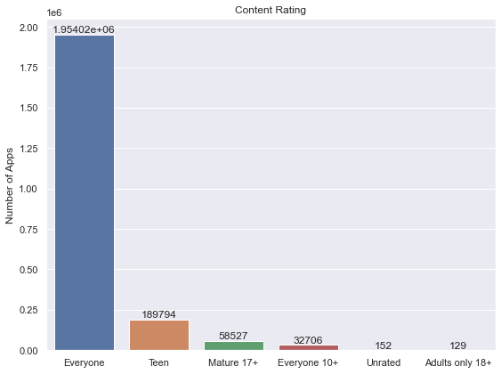

```python
content_ratings = df['Content Rating'].value_counts()

plt.figure(figsize=(8,6))
ax = sns.barplot(content_ratings.index, content_ratings.values)
ax.bar_label(ax.containers[0])

plt.xticks(rotation=0)
plt.title('Content Rating')
plt.ylabel('Number of Apps')
plt.tight_layout()
plt.show()
```

# Exploratory Data Analysis

Now, it's time to visualize the data and find insights!

**Question:** How many apps go unused (and unrated) in the Play Store?

```python
len(df[df['Average Installs'] == 0])
```

```
10973
```

**Question:** Are there more non-games than games in the Play Store?

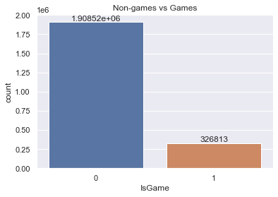

```python
game_cats = ['Strategy', 'Adventure', 'Word', 'Puzzle', 'Simulation', 'Role Playing', 'Action', 'Casual', 'Racing', 'Sports', 'Arcade', 'Card', 'Music', 'Trivia']
df['IsGame'] = 0
df.loc[df['Category'].isin(game_cats), 'IsGame'] = 1

ax = sns.countplot(df['IsGame'])
ax.bar_label(ax.containers[0])
plt.title('Non-games vs Games')

plt.show()
```

Although not that insightful, it's still shocking to see that the disparity is so large, with games only comprising 15% of the apps in the Play Store.

**Question:** What were the top 10 categories in the Google Play Store with the most apps

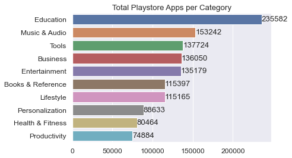

```python
plt.figure(figsize=(6,4))
sns.set(font_scale = 1.1)

categories = df['Category'].value_counts()
top10categories = categories.nlargest(10)
plt.title('Total Playstore Apps per Category')
ax = sns.barplot(y=top10categories.index, x=top10categories.values)
ax.bar_label(ax.containers[0])

plt.show()
```

Surprisingly, educational apps far outrank its counterparts in terms of volume in the Google Play Store. I initially expected one of Entertainment or Gaming categories to top the chart.

However, when we consider the **total installs for each category**, the data tells a different story.

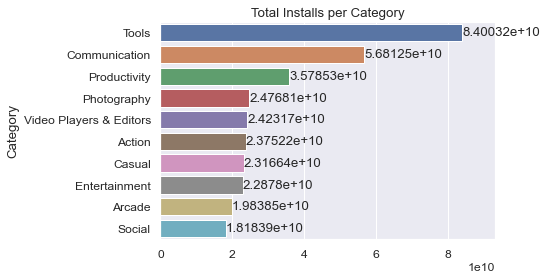

```python
plt.figure(figsize=(6,4))
sns.set(font_scale = 1.1)

total_installs_per_category = df.groupby('Category')['Average Installs'].sum()
total_installs_sorted = total_installs_per_category.sort_values(ascending = False).nlargest(10)
plt.title('Total Installs per Category')

ax = sns.barplot(y=total_installs_sorted.index, x=total_installs_sorted.values)
ax.bar_label(ax.containers[0])

plt.xlim([0, max(total_installs_sorted) * 1.11])

plt.show()
```

From the top of the rankings, it isn't surprising to see that the Tools category has the most installs, since an earlier query revealed that Google Play Services was the most installed app in the Play Store. Another interesting thing to note is that some categories, despite having lesser total apps, has relatively large total installations (such as Video Players & Editors and Photography). Thinking intuitively from a consumer's perspective, this makes sense, since there are often 'app conventions' in these categories (i.e using Lightroom to touch up photos, using Youtube to watch videos).

**Question:** What was the most installed game per category?

```python
most_installed = df[df['IsGame'] == 1].groupby('Category')['Average Installs'].idxmax()

# for the plot labels and ticks
categories = list(most_installed.index)
most_installed_apps = df.iloc[most_installed].sort_values(by='Average Installs', ascending = False)

# get the data in plot-ready form
bar_ticks = most_installed_apps['Category']
bar_labels = list(most_installed_apps['App Name'])
bar_values = list(most_installed_apps['Average Installs'])
```

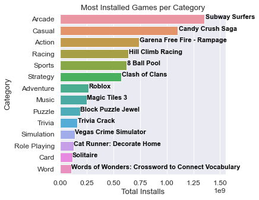

```python
#plot the figure

fig, ax = plt.subplots(figsize=(5,5))
plot = sns.barplot(y=bar_ticks, x=bar_values)

def add_label(plot):
    """Labels bars in barplot"""
    for i, rect in enumerate(plot.containers[0]):
        width = rect.get_width()
        height = rect.get_height()
        ax.text(width * 1.01, i, bar_labels[i], fontsize='small', fontweight='semibold', color='black')

add_label(plot)
plt.xlabel("Total Installs")
plt.title('Most Installed Games per Category')
plt.xlim([0, max(bar_values) * 1.15])
plt.show()
```

Immediately, some very familiar names start to show up! How many can you recognize from the list above?

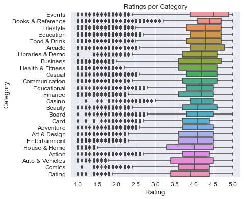

```python
plt.figure(figsize=(6,6))

median_ratings = df[df['Rating'] > 0].groupby('Category')['Rating'].median()[:25]
plot_order = median_ratings.sort_values(ascending = False).index
plt.title('Ratings per Category')
sns.boxplot(x='Rating', y='Category', data=df[df['Rating'] > 0], order=plot_order)

plt.show()
```

**Question:** Does having the 'Editors Choice' label affect your app's performance?

First, I wanted to look at the categorical distribution of Editor's Choice Apps.

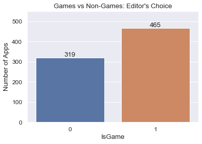

```python
editors_choice = df[df['Editors Choice'] == 1]

ax = sns.countplot(editors_choice['IsGame'])
ax.bar_label(ax.containers[0])
plt.ylabel('Number of Apps')
plt.title("Games vs Non-Games: Editor's Choice")
plt.ylim([0,550])
plt.show()
```

Per Google, Editors Choice apps were "*the apps and games that introduce users to the best innovative, creative, and designer apps on Android*". So it's clear to say that innovation (at least what's defined by the Play Store team) seems to have been more apparent from games.

Next, we'll see what effect it has on app installs and ratings.

```python
# average install and ratings of editors choice and non editors choice apps
editors_rating = df[df['Rating'] > 0].groupby('Editors Choice')['Rating'].mean()
editors_installs = df[df['Average Installs'] > 0].groupby('Editors Choice')['Average Installs'].mean()
```

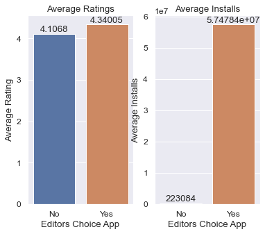

```python
plt.figure(figsize=(6,5))

plt.subplot(121)
ax = sns.barplot(x=editors_rating.index, y=editors_rating.values)
ax.bar_label(ax.containers[0])
plt.xticks(ticks=[1,0], labels=['Yes', 'No'])
plt.xlabel('Editors Choice App')
plt.ylabel('Average Rating')
plt.title('Average Ratings')

plt.subplot(122)
ax = sns.barplot(x=editors_installs.index, y=editors_installs.values)
ax.bar_label(ax.containers[0])
plt.xticks(ticks=[1,0], labels=['Yes', 'No'])
plt.xlabel('Editors Choice App')
plt.ylabel('Average Installs')
plt.title('Average Installs')
plt.show()
```

We can infer that installations play a larger role for an app to be labelled as an 'Editors Choice' app rather than mean ratings. This makes sense, since an app with two 5-star ratings (mean rating of 5) and an app with five thousand ratings that average to around 4.5 doesn't make the first app better simply because it has a higher rating!

## Let's talk about trends, shall we?

**Question:** Which year saw the most apps released? (Excluding 2021)*

**Since the data was scraped on June 2021, the entries for 2021 aren't complete yet at the time.*

```python
#get the release year
years = df['Released'].apply(lambda x: x.year)

release_years = years.value_counts()
release_years = release_years.reset_index()
release_years.rename(columns={"index":"year"}, inplace=True)
release_years.sort_values(by='year', ascending = False, inplace=True)
```

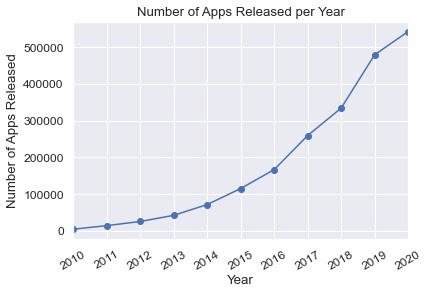

```python
#plot the graph

plt.plot(release_years['year'], release_years['Released'], marker='o')

plt.xlabel('Year')
plt.ylabel('Number of Apps Released')
plt.xticks([i for i in range(2010,2022)], rotation=30)
plt.xlim([2010,2020])

plt.title('Number of Apps Released per Year')

plt.show()
```

```python
# getting the largest increase
int(release_years[release_years['year'] == 2019]['Released']) - int(release_years[release_years['year'] == 2018]['Released'])
```

```
145006
```

**Question:** How has the volume of highly rated apps changed throughout the years?

*For this question, I will consider 'highly rated apps' as apps with ratings over 4.5 and installations of at least 10000*

```python
highly_rated = df[(df['Rating'] > 4.5) & (df['Average Installs'] > 10000)]
highly_rated['Release Year'] = highly_rated['Released'].apply(lambda x: x.year)
highly_rated_years = highly_rated['Release Year'].value_counts()
```

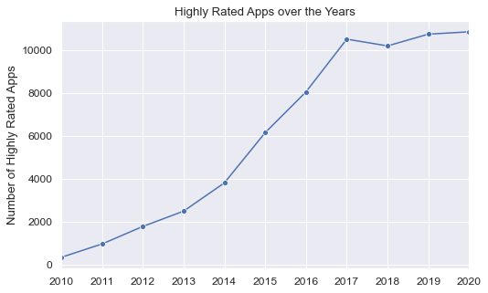

```python
fig, ax = plt.subplots(figsize=(8,5))

ax = sns.lineplot(x=highly_rated_years.index, y=highly_rated_years.values, marker='o')
plt.xticks([i for i in range(2010,2022)])
plt.ylabel('Number of Highly Rated Apps')
plt.xlim([2010,2020])
plt.title("Highly Rated Apps over the Years")


plt.show()
```

First, we have to find out the total installs per category.

```python
# returns total number of installs per category
total_installs_games = highly_rated[highly_rated['IsGame'] == 1].groupby('Category')['Average Installs'].sum().sort_values(ascending=False)

print('The top 3 gaming genres are: ' + ', '.join(total_installs_games.index[:5]))
```

```
The top 3 gaming genres are: Arcade, Casual, Puzzle, Action, Simulation
```

Then we can graph a lineplot of each category, to get a better visualization of the growth.

```python
top_rated_games = ['Arcade', 'Casual', 'Puzzle', 'Action', 'Simulation']
highly_rated_installs = highly_rated.groupby(['Release Year', 'Category'])['Average Installs'].sum()
highly_rated_installs = highly_rated_installs.reset_index()
highly_rated_installs = highly_rated_installs[highly_rated_installs['Category'].isin(top_rated_games)]

highly_rated_installs.head()
```

|  | Release Year | Category | Average Installs |
| --- | --- | --- | --- |
| 0 | 2010 | Arcade | 210,603.000 |
| 7 | 2010 | Casual | 17,827.500 |
| 25 | 2010 | Puzzle | 2,476,036.000 |
| 28 | 2010 | Simulation | 1,691,889.500 |
| 37 | 2011 | Action | 129,139.500 |

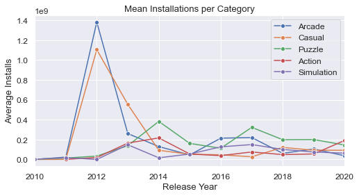

```python
arcade = highly_rated_installs[highly_rated_installs['Category'] == "Arcade"]
casual = highly_rated_installs[highly_rated_installs['Category'] == "Casual"]
puzzle = highly_rated_installs[highly_rated_installs['Category'] == "Puzzle"]
action = highly_rated_installs[highly_rated_installs['Category'] == "Action"]
simulation = highly_rated_installs[highly_rated_installs['Category'] == "Simulation"]


plt.figure(figsize=(8,4))

sns.lineplot(x=arcade['Release Year'], y=arcade['Average Installs'], marker='o', label='Arcade')
sns.lineplot(x=casual['Release Year'], y=casual['Average Installs'], marker='o', label='Casual')
sns.lineplot(x=puzzle['Release Year'], y=puzzle['Average Installs'], marker='o', label='Puzzle')
sns.lineplot(x=action['Release Year'], y=action['Average Installs'], marker='o', label='Action')
sns.lineplot(x=simulation['Release Year'], y=simulation['Average Installs'], marker='o', label='Simulation')


plt.title("Mean Installations per Category")
plt.xlim([2010,2020])
plt.legend()
plt.show()
```

For the past few years, the 'Puzzle' category has consistently had the highest average installations among the highly rated games, with 2020 being the lone exception, as action games saw a massive boost in average installation numbers this year. Games like Player Unknown's Battlegrounds (PUBG Mobile) and Garena's Free Fire battle royale games were a huge driving force, also depicted from the visualization above of the most installed games per category.

So, if you're a developer looking to dive in the mobile gaming market, these categories are a good bet, but puzzle games seem to consistently outperform other categories!

# Summary

## **Thank you for checking out my work!** 😀

The dataset was taken from [here](https://www.kaggle.com/gauthamp10/google-playstore-apps)

Check out my other work:

- [Github](https://www.github.com/garrethlee) 🐱
- [LinkedIn](https://www.linkedin.com/in/garrethlee) 🧳